# Homework5

aa2569@scarletmail.rutgers.edu

10/10/2022

## Decompose

- Data Set used - cafe

```r
library(fpp)
library(fpp2)
head(cafe)
```

```
##        Qtr1   Qtr2   Qtr3   Qtr4
## 1982        1013.2 1011.9 1166.2
## 1983 1082.5 1058.7 1118.1
```

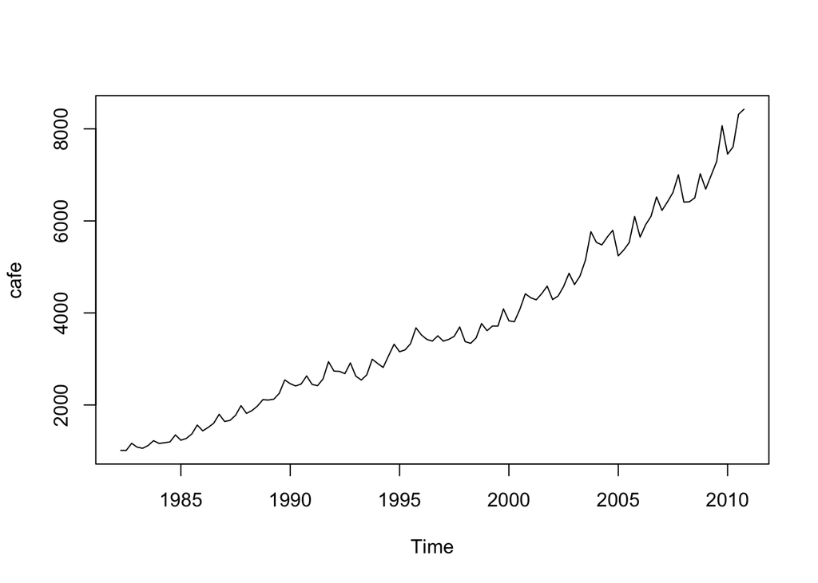

```r
plot(cafe)
```

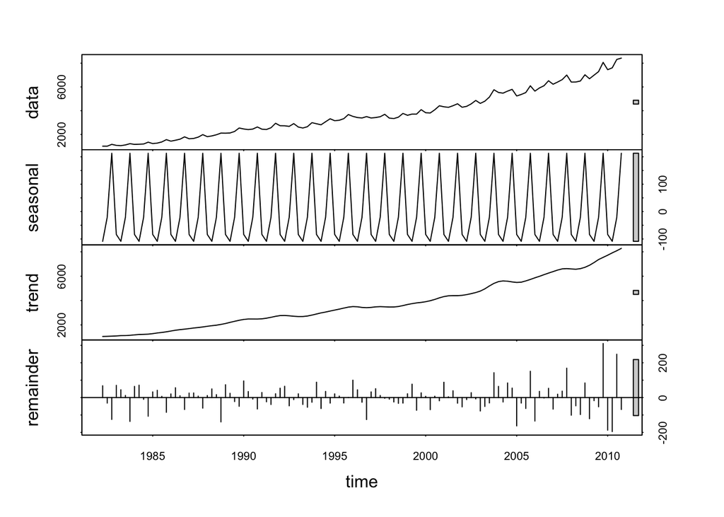

```r
stl_decomp <- stl(cafe,s.window ="periodic")
plot(stl_decomp)
```

```r
attributes(stl_decomp)
```

```
## $names
## [1] "time.series" "weights"     "call"        "win"         "deg"
## [6] "jump"        "inner"       "outer"
##
## $class
## [1] "stl"
```

- Decompose function is used to separate the the trend, seasonality and the irregularity in the data.
- From the plot above, we can see that there is a seasonality in the data and there is an upward trend.
- Towards the end of the data, the irregulairty component is observed to be increasing.

```r
seasadj(stl_decomp)
```

```
##          Qtr1     Qtr2     Qtr3     Qtr4
## 1982          1121.849 1032.686  953.177
## 1983 1166.088 1167.349 1138.886 1010.677
## 1984 1247.288 1287.449 1217.486 1136.077
## 1985 1317.088 1381.449 1390.486 1350.077
## 1986 1521.088 1621.449 1622.886 1584.377
## 1987 1723.888 1774.149 1795.786 1771.977
## 1988 1899.988 1986.549 1995.886 1901.877
## 1989 2190.288 2234.249 2274.486 2330.877
## 1990 2545.788 2521.149 2476.186 2417.177
## 1991 2529.688 2527.949 2585.686 2727.977
## 1992 2819.488 2838.549 2701.686 2700.277
## 1993 2709.288 2650.449 2674.886 2780.677
## 1994 2984.888 2923.949 3092.286 3107.277
## 1995 3240.388 3304.749 3350.986 3462.477
## 1996 3604.688 3532.649 3409.486 3289.377
## 1997 3471.188 3533.749 3512.786 3482.177
## 1998 3460.588 3447.749 3477.286 3556.577
## 1999 3697.388 3824.049 3734.886 3874.977
## 2000 3912.288 3917.949 4099.886 4202.677
## 2001 4413.588 4393.649 4439.986 4369.777
## 2002 4374.388 4475.849 4594.786 4649.477
## 2003 4699.988 4909.349 5167.386 5552.077
## 2004 5617.388 5587.049 5670.586 5583.277
## 2005 5323.788 5475.449 5548.986 5882.877
## 2006 5731.288 6023.849 6121.886 6306.977
## 2007 6311.588 6521.949 6636.586 6789.977
## 2008 6493.188 6523.449 6521.586 6811.577
## 2009 6774.588 7100.249 7312.686 7854.977
## 2010 7534.288 7716.949 8337.586 8213.477
```

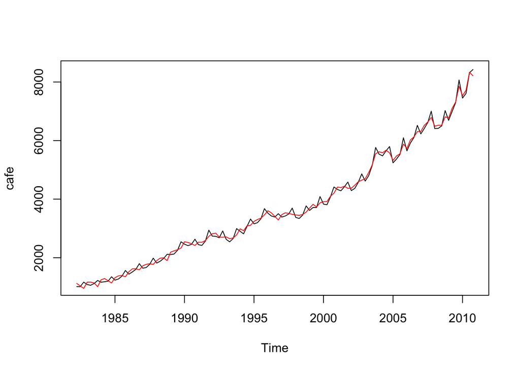

```r
plot(cafe)
lines(seasadj(stl_decomp), col="Red")
```

- The seasadj function adjusts the seasonality of the data and gives the data without the seasonal component.
- The plot above shows the data without seasonal component in Red.

```r
f_stl <- forecast(stl_decomp,h=15)
f_stl
```

```
##         Point Forecast    Lo 80     Hi 80    Lo 95     Hi 95
## 2011 Q1       8253.314 8068.755  8437.873 7971.055  8535.573
## 2011 Q2       8328.827 8083.841  8573.812 7954.153  8703.500
## 2011 Q3       8517.263 8220.718  8813.809 8063.736  8970.791
## 2011 Q4       8851.647 8508.285  9195.009 8326.520  9376.773
## 2012 Q1       8655.611 8268.359  9042.862 8063.360  9247.861
## 2012 Q2       8731.123 8301.925  9160.322 8074.721  9387.525
## 2012 Q3       8919.560 8449.762  9389.358 8201.066  9638.054
## 2012 Q4       9253.944 8744.500  9763.388 8474.816 10033.071
## 2013 Q1       9057.907 8509.499  9606.315 8219.189  9896.625
## 2013 Q2       9133.420 8546.532  9720.308 8235.853 10030.987
## 2013 Q3       9321.857 8696.828  9946.886 8365.957 10277.756
## 2013 Q4       9656.240 8993.295 10319.186 8642.353 10670.128
## 2014 Q1       9460.204 8759.480 10160.928 8388.539 10531.868
## 2014 Q2       9535.717 8797.282 10274.151 8406.379 10665.054
## 2014 Q3       9724.153 8948.021 10500.286 8537.161 10911.146
```

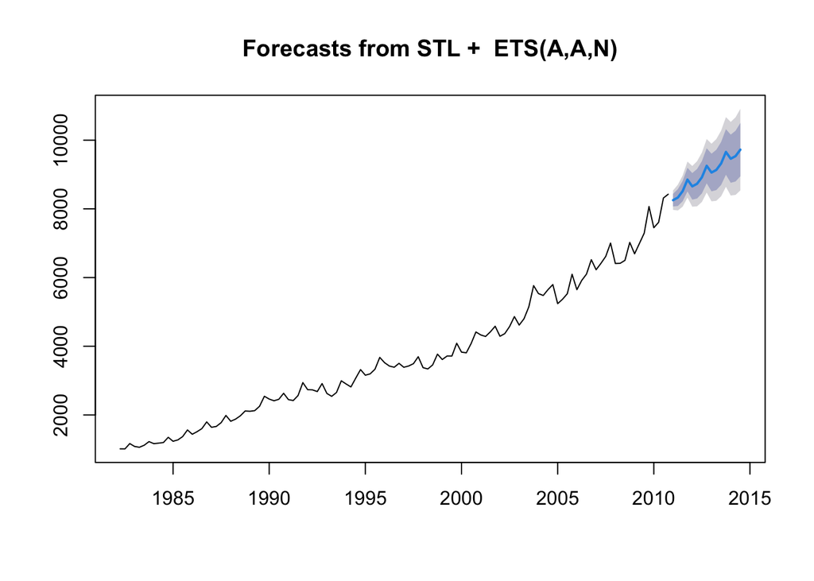

```r
plot(f_stl)
```

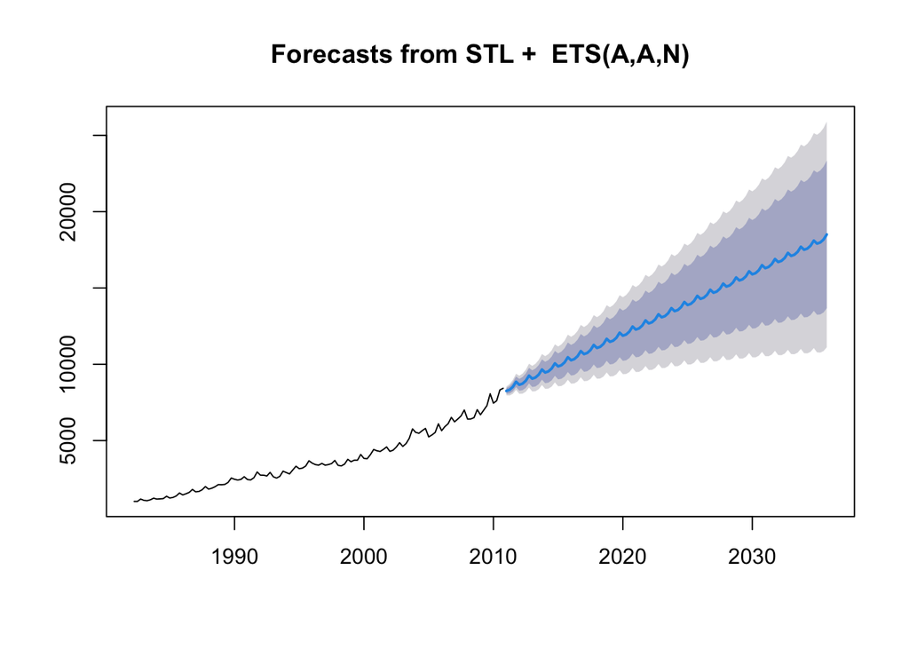

```r
f_stl2 <- forecast(stl_decomp,h=100)
plot(f_stl2)
```

- Here, the h is taken to be 100 to understand fucnction better.
- This shows us that as time period of forecast increases, the confidence interval also increases.
- Which means as the more time we forecast, the more worse our forecast is. Which makes sense.

## Another way of Decompose

```r
decomp_cafe <- decompose(cafe)

attributes(decomp_cafe)
```

```
## $names
## [1] "x"        "seasonal" "trend"    "random"   "figure"   "type"
##
## $class
## [1] "decomposed.ts"
```

```r
seasadj(decomp_cafe)
```

```
##           Qtr1      Qtr2      Qtr3      Qtr4
## 1982           1115.8476 1041.0214  954.4423
## 1983 1162.4887 1161.3476 1147.2214 1011.9423
## 1984 1243.6887 1281.4476 1225.8214 1137.3423
## 1985 1313.4887 1375.4476 1398.8214 1351.3423
## 1986 1517.4887 1615.4476 1631.2214 1585.6423
## 1987 1720.2887 1768.1476 1804.1214 1773.2423
## 1988 1896.3887 1980.5476 2004.2214 1903.1423
## 1989 2186.6887 2228.2476 2282.8214 2332.1423
## 1990 2542.1887 2515.1476 2484.5214 2418.4423
## 1991 2526.0887 2521.9476 2594.0214 2729.2423
## 1992 2815.8887 2832.5476 2710.0214 2701.5423
## 1993 2705.6887 2644.4476 2683.2214 2781.9423
## 1994 2981.2887 2917.9476 3100.6214 3108.5423
## 1995 3236.7887 3298.7476 3359.3214 3463.7423
## 1996 3601.0887 3526.6476 3417.8214 3290.6423
## 1997 3467.5887 3527.7476 3521.1214 3483.4423
## 1998 3456.9887 3441.7476 3485.6214 3557.8423
## 1999 3693.7887 3818.0476 3743.2214 3876.2423
## 2000 3908.6887 3911.9476 4108.2214 4203.9423
## 2001 4409.9887 4387.6476 4448.3214 4371.0423
## 2002 4370.7887 4469.8476 4603.1214 4650.7423
## 2003 4696.3887 4903.3476 5175.7214 5553.3423
## 2004 5613.7887 5581.0476 5678.9214 5584.5423
## 2005 5320.1887 5469.4476 5557.3214 5884.1423
## 2006 5727.6887 6017.8476 6130.2214 6308.2423
## 2007 6307.9887 6515.9476 6644.9214 6791.2423
## 2008 6489.5887 6517.4476 6529.9214 6812.8423
## 2009 6770.9887 7094.2476 7321.0214 7856.2423
## 2010 7530.6887 7710.9476 8345.9214 8214.7423
```

- decompose() function is one more way of using decompose.
- In the attribute we can see that there are trend, seasonal, and random variations.
- seasadj does the same job of adjusting the seasonal variation in the data.
- Unlike the previous decompose function, this decompose is slightly different which is shown below.

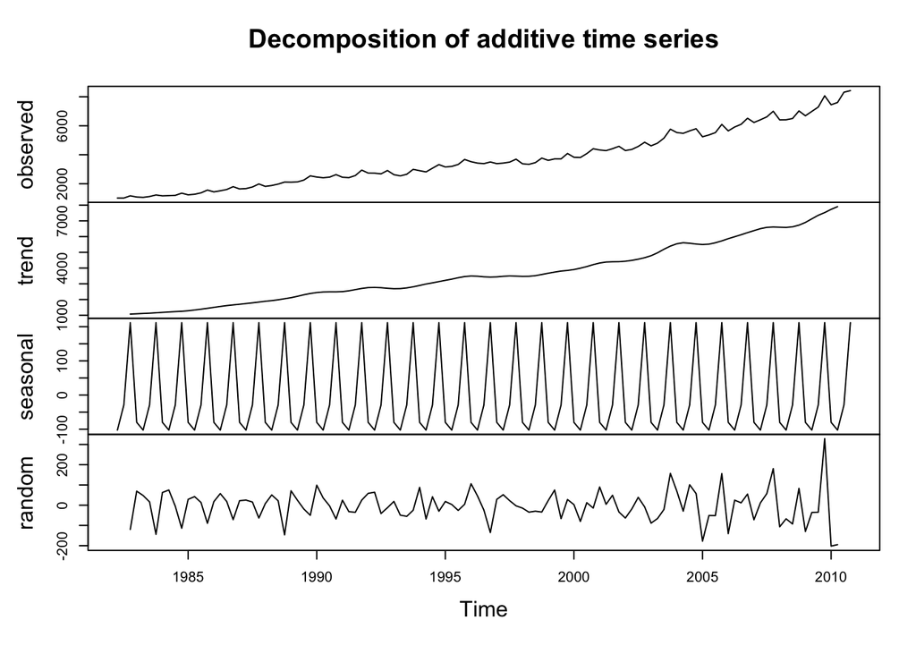

```r
plot(decomp_cafe)
```

- In the plot, it can be seen that the order of showing the trend, seasonal, and irregularity is different but the visuals are the same.
- “random” indicates the irregularity component and it is shown is a line graph for this function.